# 01_read_data

link to presentation

https://docs.google.com/presentation/d/1j092IUsKge5XvswE18HGZPmz4NGRUtOXNunP9SOr3i0/edit?usp=sharing

```r
# NOTE: що тут трапляється — команди steinbock CLI (запускаються в терміналі
# ДО будь-якого R), які з вихідних IMC-знімків генерують усі вхідні теки для аналізу.
# steinbock preprocess imc images --hpf 50
# steinbock segment deepcell --minmax
# steinbock measure intensities
# steinbock measure regionprops
# steinbock measure neighbors --type centroids --dmax 15

# NOTE: звідки беруться дані (всі теки лежать у base_path = Panel_2_10/):
#   raw/          — вихідні IMC-знімки (.mcd/.txt) з мас-цитометра (вхід для steinbock)
#   img/          — багатоканальні TIFF, з `steinbock preprocess imc images --hpf 50` з raw/
#   masks/        — маски сегментації клітин, з `steinbock segment deepcell --minmax`
#   intensities/  — середні інтенсивності маркерів на клітину, з `steinbock measure intensities`
#   regionprops/  — морфометрія клітин (площа, форма…), з `steinbock measure regionprops`
#   neighbors/    — граф сусідства клітин, з `steinbock measure neighbors --type centroids --dmax 15`
#   panel.csv, images.csv — панель з 44 маркерів і метадані знімків (надаються вручну)
#   gates/*.rds   — ручне гейтування (мітки типів клітин), експорт з cytomapperShiny - Q: do we need to add more gates?
#   *_compensation/ — TIFF-зрізи одиничних барвників для оцінки spillover (CATALYST)
#   ROut/         — вихід R: збережений spe.rds, модель тощо
```

```r
# NOTE: підключаємо всі бібліотеки Bioconductor/CRAN, потрібні для пайплайну
# (робота з SPE, компенсація CATALYST, гейти cytomapper, навчання XGBoost, графіки).
library(SingleCellExperiment)
library(caret)
library(xgboost)
library(imcRtools)
library(cytomapper)
library(dplyr)
library(dittoSeq)
library(ggplot2)
library(scater)
library(scuttle)
library(CATALYST)
library(patchwork)
library(stringr)
library(tidyverse)
library(scran)
library(viridis)
library(BiocParallel)
library(doParallel)
library(BiocNeighbors)
library(cowplot)
library(batchelor)
library(ComplexHeatmap)
library(circlize)
library(ggridges)
```

```r
# =====================================================================
# STEP 01 — Read images (steinbock outputs)
# =====================================================================
# NOTE: читаємо вихід steinbock і будуємо головний об'єкт SPE (SpatialExperiment):
# рядки = маркери IMC, колонки = клітини. Також задаємо out_dir для збереження результатів.
# NOTE: дані з intensities/, regionprops/, neighbors/, panel.csv, images.csv (вихід steinbock).
# NOTE: base_path має вказувати на реальну теку Panel_2_10 з даними steinbock.
#       Зараз стоїть ~/Desktop/...; за потреби заміни на фактичний шлях до даних.

base_path <- "/Users/svitlanamoiseyenko/Repos/genomic/xgboost-imc-panel2-cell-classifier/XGBoost_classifier/Panel_2_10"

raw_exprs_cofactor <- 5

out_dir <- file.path(base_path, "ROut")
dir.create(out_dir, showWarnings = FALSE, recursive = TRUE)

spe <- read_steinbock(base_path, return_as = "spe")

rownames(rowData(spe))
```

```
##  [1] "panCK"      "HistoneH3"  "SMA"        "CD7"        "CD11b"
##  [6] "Arg1"       "CD146"      "EGFR"       "CD45"       "CD31"
## [11] "MMP9"       "CD20"       "CD204"      "p53"        "CD3"
## [16] "Lamp3"      "CD11c"      "PD1"        "CD73"       "Bcl2"
## [21] "GATA3"      "CD155"      "CD10"       "NKG2A"      "FOXP3"
## [26] "CXCL13"     "CD8a"       "EOMES"      "CD137"      "CD134"
## [31] "CD209"      "CD56"       "Tbet"       "GITR"       "Ecad"
## [36] "Tim3"       "CXCL8"      "CD66b"      "DNA1"       "DNA2"
## [41] "Ki67"       "Podoplanin" "IgG"        "CD15"
```

# spillover

```r
# =====================================================================
# STEP 02 — Compensate (spillover correction)
# =====================================================================
# NOTE:
# we need to have IMMUcan_panel_2_2.10_compensation/ all think how to re-point
# Spillover в IMC (Imaging Mass Cytometry) — це коли сигнал одного металу "протікає" в інший канал.
# читаємо TIFF-зрізи одиничних барвників (compensation slide) у окремий об'єкт sceTIFF —
# вони потрібні, щоб оцінити spillover-матрицю між каналами металів.
# NOTE: дані з *_compensation/ (підтеки img/, та images.csv, panel.csv цієї теки).
comp_path <- list.files(base_path, pattern = "compensation$", full.names = TRUE)

img_path <- file.path(comp_path, "img")
image_csv <- file.path(comp_path, "images.csv")
panel_csv <- file.path(comp_path, "panel.csv")

sceTIFF <- readSCEfromTIFF(
  x = img_path,
  image_df_path = image_csv,
  panel_df_path = panel_csv
)
```

```
## Spotted channels:  Y89, In113, In115, Pr141, Nd142, Nd143, Nd144, Nd145, Nd146, Sm147, Nd148, Sm149, Nd150, Eu151, Sm152, Eu153, Sm154, Gd155, Gd156, Gd158, Tb159, Gd160, Dy161, Dy162, Dy163, Dy164, Ho165, Er166, Er167, Er168, Tm169, Er170, Yb171, Yb172, Yb173, Yb174, Lu175, Yb176, Pt194, Pt195, …
## Acquired channels:  ArAr80, Y89, In113, In115, Xe131, Xe134, Ba136, La138, Pr141, Nd142, Nd143, Nd144, Nd145, Nd146, Sm147, Nd148, Sm149, Nd150, Eu151, Sm152, Eu153, Sm154, Gd155, Gd156, Gd158, Tb159, Gd160, Dy161, Dy162, Dy163, Dy164, Ho165, Er166, Er167, Er168, Tm169, Er170, Yb171, Yb172, Yb173…
## Channels spotted but not acquired:
## Channels acquired but not spotted:  ArAr80, Xe131, Xe134, Ba136, La138, Ir191, Ir193, Pt198, Pb206
```

```r
sceTIFF$Panel <- basename(base_path)
sceTIFF
```

```
## class: SingleCellExperiment
## dim: 51 84000
## metadata(0):
## assays(1): counts
## rownames(51): ArAr80 Y89 ... Pb206 Bi209
## rowData names(2): channel_name marker_name
## colnames: NULL
## colData names(5): cell_id sample_id sample_metal sample_mass Panel
## reducedDimNames(0):
## mainExpName: NULL
## altExpNames(0):
```

```r
#TODO: visualise ....
```

# comp assay

```r
# NOTE: CATALYST-обробка compensation-зрізів: asinh-трансформація, дебаркодинг пікселів
# (assignPrelim/estCutoffs/applyCutoffs), фільтр пікселів і обчислення spillover-матриці.
compensation_pixel_exprs_cofactor <- 5
compensated_exprs_cofactor <- 1

process_comp_sce <- function(x, minevents = 40) {
  assay(x, "exprs") <- asinh(counts(x) / compensation_pixel_exprs_cofactor)

  bc_key <- as.numeric(unique(x$sample_mass))
  bc_key <- bc_key[order(bc_key)]

  x <- assignPrelim(x, bc_key = bc_key)
  x <- estCutoffs(x)
  x <- applyCutoffs(x)

  x <- filterPixels(
    x,
    minevents = minevents,
    correct_pixels = TRUE
  )

  x <- computeSpillmat(x)

  x
}

sceTIFF <- process_comp_sce(sceTIFF)
sceTIFF
```

```
## class: SingleCellExperiment
## dim: 51 84000
## metadata(4): bc_key sep_cutoffs mhl_cutoff spillover_matrix
## assays(3): counts exprs scaled
## rownames(51): ArAr80 Y89 ... Pb206 Bi209
## rowData names(3): channel_name marker_name is_bc
## colnames: NULL
## colData names(8): cell_id sample_id ... delta mhl_dist
## reducedDimNames(0):
## mainExpName: NULL
## altExpNames(0):
```

```r
# NOTE: правимо першу назву каналу в spillover-матриці на "Ar80Di" і додаємо аргон (Ar=80)
# до списку ізотопів, щоб канал коректно розпізнавався далі.
spillover_matrix <- metadata(sceTIFF)$spillover_matrix
colnames(spillover_matrix)[1] <- "Ar80Di"
metadata(sceTIFF)$spillover_matrix <- spillover_matrix

isotope_list <- CATALYST::isotope_list
isotope_list$Ar <- 80
```

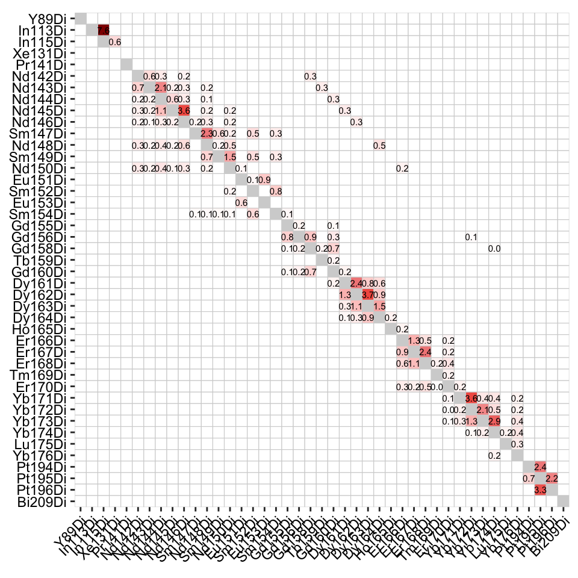

```r
# NOTE: візуалізуємо spillover-матрицю (теплова карта перетікання сигналу між каналами).
# NOTE:Як читати графік?
# Рядки = канал-джерело сигналу.

# Стовпці = канал, куди сигнал "протікає".
# Чим червоніше — тим сильніший spillover.
# Число в клітинці = відсоток spillover.

plotSpillmat(sceTIFF, isotope_list = isotope_list)
```

```r
# NOTE: застосовуємо spillover-компенсацію до головного SPE через compCytof():
# перезаписуємо assay-и counts/exprs компенсованими значеннями і зберігаємо spe.rds у ROut/.
sm <- metadata(sceTIFF)$spillover_matrix
colnames(sm)[1] <- "Ar80Di"

# write.csv(sm, file.path(out_dir, "sm.csv"))

rowData(spe)$channel_name <- paste0(rowData(spe)$channel, "Di")

spe <- compCytof(
  spe,
  sm,
  transform = TRUE,
  cofactor = compensated_exprs_cofactor,
  isotope_list = isotope_list,
  overwrite = FALSE
)

# Keep an uncompensated copy for before/after spillover QC.
# counts is still the raw steinbock signal at this point; build a matching
# asinh exprs assay on the same cofactor so the two scatters are comparable.
spe_uncomp <- spe
assay(spe_uncomp, "exprs") <- asinh(assay(spe_uncomp, "counts") / compensated_exprs_cofactor)

assay(spe, "counts") <- assay(spe, "compcounts")
assay(spe, "exprs") <- assay(spe, "compexprs")

assay(spe, "compcounts") <- NULL
assay(spe, "compexprs") <- NULL
# already with comp assay
spe
```

```
## class: SpatialExperiment
## dim: 44 250568
## metadata(0):
## assays(2): counts exprs
## rownames(44): panCK HistoneH3 ... IgG CD15
## rowData names(7): channel name ... Tube.Number channel_name
## colnames(250568): 10123864-USL-VAR-TIS-01-IMC-02_001_1
##   10123864-USL-VAR-TIS-01-IMC-02_001_2 ...
##   10123900-USL-VAR-TIS-01-IMC-02_003_2988
##   10123900-USL-VAR-TIS-01-IMC-02_003_2989
## colData names(8): sample_id ObjectNumber ... width_px height_px
## reducedDimNames(0):
## mainExpName: NULL
## altExpNames(0):
## spatialCoords names(2) : Pos_X Pos_Y
## imgData names(1): sample_id
```

```r
# TODO: check  ROut -> Rout
# saveRDS(spe, file.path(base_path, "ROut", "spe.rds"))
saveRDS(spe, file.path(base_path, "Rout", "spe.rds"))
```

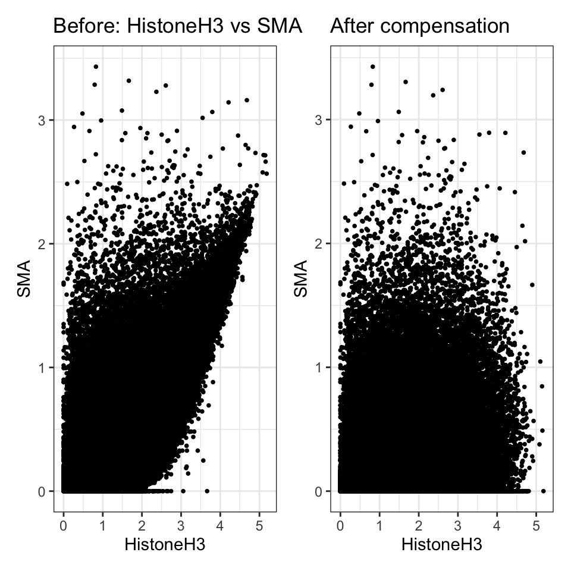

```r
# ADDED: but need to think more
# NOTE: QC компенсації — пара каналів з найсильнішим spillover, до vs після компенсації.
# Restrict to channels present in spe, find the strongest spillover pair, map to markers.
valid_ch <- intersect(rownames(sm), rowData(spe)$channel_name)
sm_sub   <- sm[valid_ch, valid_ch]
diag(sm_sub) <- 0

ij      <- which(sm_sub == max(sm_sub, na.rm = TRUE), arr.ind = TRUE)[1, ]
src_ch  <- rownames(sm_sub)[ij[1]]   # source channel (bleeds out)
tgt_ch  <- colnames(sm_sub)[ij[2]]   # target channel (receives bleed)

ch2marker  <- setNames(rownames(spe), rowData(spe)$channel_name)
src_marker <- ch2marker[[src_ch]]
tgt_marker <- ch2marker[[tgt_ch]]

p_before <- dittoSeq::dittoScatterPlot(
  spe_uncomp, x.var = src_marker, y.var = tgt_marker,
  assay.x = "exprs", assay.y = "exprs"
) + ggtitle(paste0("Before: ", src_marker, " vs ", tgt_marker))

p_after <- dittoSeq::dittoScatterPlot(
  spe, x.var = src_marker, y.var = tgt_marker,
  assay.x = "exprs", assay.y = "exprs"
) + ggtitle("After compensation")

p_before + p_after   # patchwork (already loaded)
```

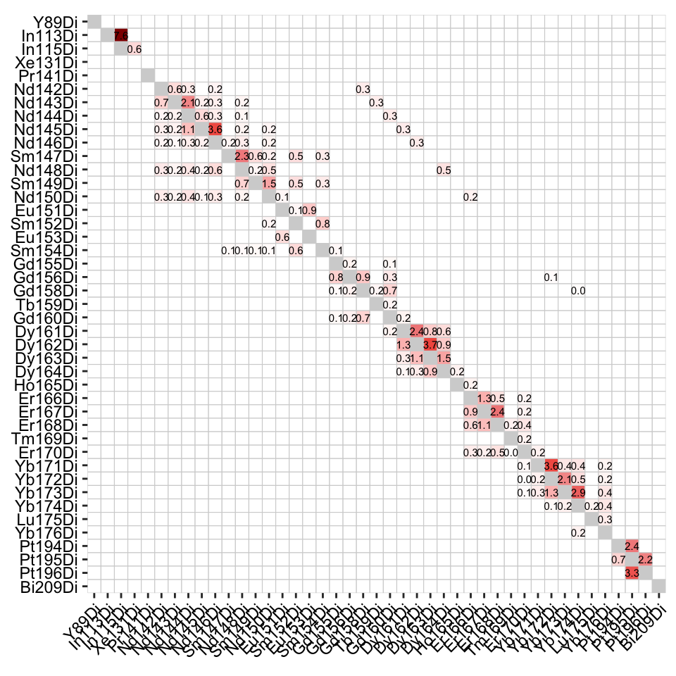

```r
# NOTE: візуалізуємо spillover-матрицю (теплова карта перетікання сигналу між каналами). - AFTER
# TODO: check if visualisation is correct taken
# NOTE: seems we don't have some significant  difference after


plotSpillmat(sceTIFF, isotope_list = isotope_list)
```

Now we rewrote the assays in our spe to compensated

## already gated (labelled) images

USL - the group of colorectal cancer (CRC) tissue samples/patients that came from University Saint-Luc (Brussels)

```r
# =====================================================================
# STEP 04 — Label (manual gates)
# =====================================================================
# TODO: probably we can generate more gates
# NOTE: читаємо ручні гейти (.rds), нормалізуємо назви міток (прибираємо суфікси _NN,
# Cd4->CD4, MDSC_->MDSC, Cd8->CD8) і матчимо до клітин SPE через cell_id = sample_id_ObjectNumber.
# NOTE: дані з gates/*.rds (ручне гейтування, експорт з cytomapperShiny).
# spe <- readRDS(file.path(base_path, "ROut", "spe.rds"))
spe <- readRDS(file.path(base_path, "Rout", "spe.rds"))

gates <- list.files(
  file.path(base_path, "gates"),
  pattern = "\\.rds$",
  full.names = TRUE,
  recursive = TRUE
)

gate_labels <- purrr::map_dfr(gates, function(path) {
  x <- readRDS(path)

  data.frame(
    sample_id = as.character(x$sample_id),
    ObjectNumber = as.character(x$ObjectNumber),
    cytomapper_CellLabel = as.character(x$cytomapper_CellLabel),
    gate_file = basename(path),
    row.names = NULL
  )
})

gate_labels$cytomapper_CellLabel <- sub(
  "_[0-9]+[a-zA-Z]?$",
  "",
  gate_labels$cytomapper_CellLabel
)

gate_labels$cytomapper_CellLabel <- sub(
  " \\([0-9]+\\)$",
  "",
  gate_labels$cytomapper_CellLabel
)

gate_labels$cytomapper_CellLabel[gate_labels$cytomapper_CellLabel == "Cd4"] <- "CD4"
gate_labels$cytomapper_CellLabel[gate_labels$cytomapper_CellLabel == "MDSC_"] <- "MDSC"
gate_labels$cytomapper_CellLabel[gate_labels$cytomapper_CellLabel == "Cd8"] <- "CD8"


gate_labels$cell_id <- paste0(gate_labels$sample_id, "_", gate_labels$ObjectNumber)

sum(gate_labels$cell_id %in% colnames(spe))
```

```
## [1] 33386
```

```r
nrow(gate_labels)
```

```
## [1] 87152
```

# img, masks

```r
# =====================================================================
# STEP 03 — Segment (cells + masks)
# =====================================================================
# NOTE: відбираємо лише гейтовані клітини, що є в SPE, визначаємо 28 гейтованих знімків
# і завантажуємо для них багатоканальні зображення та маски сегментації.
# NOTE: дані з img/ (зображення) і masks/ (маски сегментації).
matched_gate_labels <- gate_labels[
  gate_labels$cell_id %in% colnames(spe),
]

images_28 <- sort(unique(matched_gate_labels$sample_id))

images_28_pattern <- paste0(
  "^",
  images_28,
  "[.]tiff$",
  collapse = "|"
)

images_28_obj <- loadImages(
  file.path(base_path, "img"),
  pattern = images_28_pattern
)

images_28_obj <- images_28_obj[images_28]
channelNames(images_28_obj) <- rownames(spe)

masks_28 <- loadImages(
  file.path(base_path, "masks"),
  pattern = images_28_pattern,
  as.is = TRUE
)

masks_28 <- masks_28[names(images_28_obj)]

S4Vectors::mcols(images_28_obj) <- S4Vectors::mcols(masks_28) <-
  S4Vectors::DataFrame(sample_id = names(images_28_obj))

spe_28 <- spe[, spe$sample_id %in% names(images_28_obj)]

images_28
```

```
##  [1] "10123868-USL-VAR-TIS-01-IMC-02_001" "10123869-USL-VAR-TIS-01-IMC-02_003"
##  [3] "10123871-USL-VAR-TIS-01-IMC-02_001" "10123873-USL-VAR-TIS-01-IMC-02_003"
##  [5] "10123874-USL-VAR-TIS-01-IMC-02_002" "10123874-USL-VAR-TIS-01-IMC-02_003"
##  [7] "10123875-USL-VAR-TIS-01-IMC-02_001" "10123876-USL-VAR-TIS-01-IMC-02_002"
##  [9] "10123876-USL-VAR-TIS-01-IMC-02_003" "10123878-USL-VAR-TIS-01-IMC-02_003"
## [11] "10123879-USL-VAR-TIS-01-IMC-02_003" "10123880-USL-VAR-TIS-01-IMC-02_002"
## [13] "10123881-USL-VAR-TIS-01-IMC-02_001" "10123882-USL-VAR-TIS-01-IMC-02_003"
## [15] "10123883-USL-VAR-TIS-01-IMC-02_005" "10123884-USL-VAR-TIS-01-IMC-02_002"
## [17] "10123885-USL-VAR-TIS-01-IMC-02_003" "10123886-USL-VAR-TIS-01-IMC-02_002"
## [19] "10123887-USL-VAR-TIS-01-IMC-02_001" "10123887-USL-VAR-TIS-01-IMC-02_002"
## [21] "10123888-USL-VAR-TIS-01-IMC-02_002" "10123892-USL-VAR-TIS-01-IMC-02_001"
## [23] "10123892-USL-VAR-TIS-01-IMC-02_002" "10123893-USL-VAR-TIS-01-IMC-02_002"
## [25] "10123894-USL-VAR-TIS-01-IMC-02_002" "10123895-USL-VAR-TIS-01-IMC-02_003"
## [27] "10123897-USL-VAR-TIS-01-IMC-02_002" "10123899-USL-VAR-TIS-01-IMC-02_003"
```

# Img QC

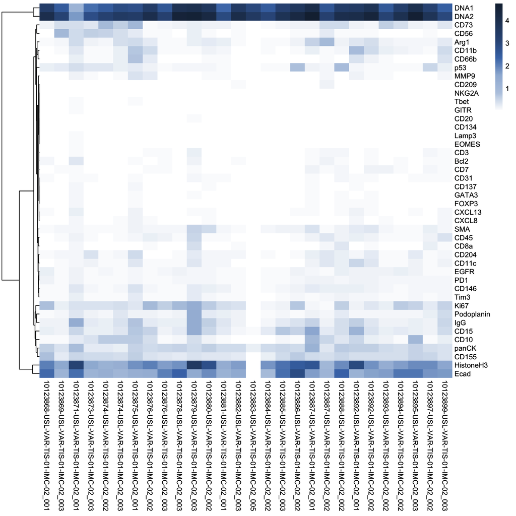

```r
# NOTE: QC на рівні знімків — рахуємо середню експресію маркерів по кожному знімку
# і малюємо теплову карту, щоб виявити порожні/аномальні зображення.
image_mean <- aggregateAcrossCells(spe_28,
                                   ids = spe_28$sample_id,
                                   statistics="mean",
                                   use.assay.type = "counts")

assay(image_mean, "exprs") <- asinh(assay(image_mean, "counts"))

genes_to_plot <- rownames(image_mean)[
  rowSums(assay(image_mean, "exprs") != 0, na.rm = TRUE) > 0
]
if (length(genes_to_plot) == 0) {
  stop("No selected markers have non-zero image-level expression values.")
}

dittoHeatmap(
  image_mean,
  genes = genes_to_plot,
  assay = "exprs",
  cluster_cols = FALSE,
  scale = "none",
  heatmap.colors = colorRampPalette(c(
    "white",
    "#B8CAE2", "#9EB7D8", "#4575B4", "#325584", "#264164", "#182A40"
  ))(100),
  show_colnames = TRUE
)
```

delete 1 blank image from analysis

```r
# NOTE: data clean
# NOTE: прибираємо 1 порожній знімок з аналізу (28 -> 27 знімків) у SPE, зображеннях, масках і гейтах.
spe_27 <- spe_28[
  ,
  spe_28$sample_id != "10123883-USL-VAR-TIS-01-IMC-02_005"
]

images_27 <- setdiff(
  names(images_28_obj),
  "10123883-USL-VAR-TIS-01-IMC-02_005"
)

images_27_obj <- images_28_obj[images_27]
masks_27 <- masks_28[images_27]

gate_labels <- gate_labels[
  gate_labels$sample_id != "10123883-USL-VAR-TIS-01-IMC-02_005",
]
```

## gating via cymoviewer

```r
# NOTE: перевіряємо, що id зображень, масок і SPE повністю збігаються, і записуємо
# узгоджені mcols (sample_id) для зображень та масок — підготовка до cytomapperShiny.
image_ids <- names(images_27_obj)
mask_ids <- names(masks_27)
spe_ids <- unique(as.character(spe_27$sample_id))

stopifnot(
  identical(image_ids, mask_ids),
  setequal(image_ids, spe_ids),
  !anyDuplicated(image_ids)
)

cur_mcols <- S4Vectors::DataFrame(
  image = image_ids,
  sample_id = image_ids,
  name = image_ids,
  row.names = image_ids
)

mcols(images_27_obj) <- cur_mcols
mcols(masks_27)      <- cur_mcols


identical(mcols(images_27_obj), mcols(masks_27))
```

```
## [1] TRUE
```

```r
identical(mcols(images_27_obj)$sample_id, names(masks_27))
```

```
## [1] TRUE
```

```r
setequal(
  mcols(images_27_obj)$sample_id,
  unique(as.character(spe_27$sample_id))
)
```

```
## [1] TRUE
```

```r
# NOTE: інтерактивне гейтування/перегляд клітин у cytomapperShiny (лише в інтерактивній сесії RStudio).
# TODO: check maybe we need more
if (interactive()) {
  cytomapperShiny(object = spe_27, mask = masks_27, image = images_27_obj,
                  cell_id = "ObjectNumber", img_id = "sample_id")
}
```

## cells assigned to the same class multiple times

```r
# NOTE: будуємо матрицю клітина x мітка і шукаємо клітини, яким одну й ту саму мітку
# присвоїли кілька разів (same-label duplicates).
cur_tab <- unclass(table( #make a mat no table class
  gate_labels$cell_id,
  gate_labels$cytomapper_CellLabel
))

cur_tab_raw <- cur_tab

same_label_duplicate_ids <- rownames(cur_tab_raw)[rowSums(cur_tab_raw > 1) > 0]

if (length(same_label_duplicate_ids) > 0) {
  cur_tab_raw[same_label_duplicate_ids, , drop = FALSE]
} else {
  print("No same-label duplicated gates found.")
}
```

```
##
##                                           B BnT CD4 CD8 DC Fibro Igg MDSC Mac
##   10106513-CLB-VAR-TIS-01-IMC-02_001_27   0   0   0   0  0     0   0    2   0
##   10106518-CLB-VAR-TIS-01-IMC-02_003_2150 0   0   0   0  0     0   0    2   0
##   10106554-CLB-VAR-TIS-02-IMC-02_003_1395 0   0   0   0  0     0   0    2   0
##   10106554-CLB-VAR-TIS-02-IMC-02_003_1505 0   0   0   0  0     0   0    2   0
##   10106554-CLB-VAR-TIS-02-IMC-02_003_731  0   0   0   0  0     0   0    2   0
##   10106554-CLB-VAR-TIS-02-IMC-02_003_759  0   0   0   0  0     0   0    2   0
##   10106554-CLB-VAR-TIS-02-IMC-02_003_794  0   0   0   0  0     0   0    2   0
##   10106554-CLB-VAR-TIS-02-IMC-02_003_924  0   0   0   0  0     0   0    2   0
##   10106562-CLB-VAR-TIS-01-IMC-02_002_1424 0   0   0   0  0     0   0    2   0
##   10106562-CLB-VAR-TIS-01-IMC-02_002_1519 0   0   0   0  0     0   0    2   0
##   10106562-CLB-VAR-TIS-01-IMC-02_002_903  0   0   0   0  0     0   0    2   0
##   10106562-CLB-VAR-TIS-01-IMC-02_002_982  0   0   0   0  0     0   0    2   0
##   10106565-CLB-VAR-TIS-02-IMC-02_002_2593 0   0   0   0  0     2   0    0   0
##   10117062-DED-VAR-TIS-UNST-04_002_2127   0   0   0   0  0     0   0    2   0
##   10117066-DED-VAR-TIS-UNST-04_002_1641   0   0   0   0  0     0   0    2   0
##   10123869-USL-VAR-TIS-01-IMC-02_003_1002 0   0   0   0  0     0   0    2   0
##   10123869-USL-VAR-TIS-01-IMC-02_003_297  0   0   0   0  0     0   0    2   0
##   10123874-USL-VAR-TIS-01-IMC-02_002_355  0   0   0   0  0     0   0    2   0
##   10123874-USL-VAR-TIS-01-IMC-02_002_534  0   0   0   0  0     0   0    2   0
##   10123874-USL-VAR-TIS-01-IMC-02_003_126  0   0   0   0  0     0   0    2   0
##   10123874-USL-VAR-TIS-01-IMC-02_003_1693 0   0   0   0  0     0   0    2   0
##   10123874-USL-VAR-TIS-01-IMC-02_003_1723 0   0   0   0  0     0   0    2   0
##   10123874-USL-VAR-TIS-01-IMC-02_003_2008 0   0   0   0  0     0   0    2   0
##   10123874-USL-VAR-TIS-01-IMC-02_003_2113 0   0   0   0  0     0   0    2   0
##   10123874-USL-VAR-TIS-01-IMC-02_003_2254 0   0   0   0  0     0   0    2   0
##   10123874-USL-VAR-TIS-01-IMC-02_003_715  0   0   0   0  0     0   0    2   0
##   10123876-USL-VAR-TIS-01-IMC-02_002_2329 0   0   0   0  0     0   0    2   0
##   10123880-USL-VAR-TIS-01-IMC-02_002_1251 0   0   0   0  0     0   0    2   0
##   10123884-USL-VAR-TIS-01-IMC-02_002_1003 0   0   0   0  0     0   0    2   0
##   10123887-USL-VAR-TIS-01-IMC-02_001_1511 0   0   0   0  0     0   0    2   0
##   10123887-USL-VAR-TIS-01-IMC-02_001_1747 0   0   0   0  0     0   0    2   0
##   10123892-USL-VAR-TIS-01-IMC-02_002_126  0   0   0   0  0     0   0    2   0
##   10123893-USL-VAR-TIS-01-IMC-02_002_1425 0   0   0   0  0     0   0    2   0
##   10123893-USL-VAR-TIS-01-IMC-02_002_2297 0   0   0   0  0     0   0    2   0
##   10123893-USL-VAR-TIS-01-IMC-02_002_2451 0   0   0   0  0     0   0    2   0
##   10123893-USL-VAR-TIS-01-IMC-02_002_2499 0   0   0   0  0     0   0    2   0
##   10123893-USL-VAR-TIS-01-IMC-02_002_74   0   0   0   0  0     0   0    2   0
##   10123893-USL-VAR-TIS-01-IMC-02_002_837  0   0   0   0  0     0   0    2   0
```

[output cut: 149 more lines]

```
##   10123893-USL-VAR-TIS-01-IMC-02_002_2451      0         0    0
##   10123893-USL-VAR-TIS-01-IMC-02_002_2499      0         0    0
##   10123893-USL-VAR-TIS-01-IMC-02_002_74        0         0    0
##   10123893-USL-VAR-TIS-01-IMC-02_002_837       0         0    0
##   10123894-USL-VAR-TIS-01-IMC-02_002_2934      0         0    0
##   10123894-USL-VAR-TIS-01-IMC-02_002_3494      0         0    0
##   10123894-USL-VAR-TIS-01-IMC-02_002_3681      0         0    0
##   10123894-USL-VAR-TIS-01-IMC-02_002_3734      0         0    0
##   10123894-USL-VAR-TIS-01-IMC-02_002_3838      0         0    0
##   10123894-USL-VAR-TIS-01-IMC-02_002_3892      0         0    0
##   10123894-USL-VAR-TIS-01-IMC-02_002_3939      0         0    0
##   10123899-USL-VAR-TIS-01-IMC-02_003_13        0         0    0
##   10123899-USL-VAR-TIS-01-IMC-02_003_174       0         0    0
##   10123899-USL-VAR-TIS-01-IMC-02_003_436       0         0    0
##   10123899-USL-VAR-TIS-01-IMC-02_003_879       0         0    0
```

```r
# NOTE: зводимо лічильники до 0/1 і знаходимо справжні doublets — клітини з кількома РІЗНИМИ мітками.
cur_tab <- cur_tab_raw
cur_tab[cur_tab > 1] <- 1

# True multi-label doublets
multi_label_doublet_ids <- rownames(cur_tab)[rowSums(cur_tab) > 1]

if (length(multi_label_doublet_ids) > 0) {
  head(cur_tab[multi_label_doublet_ids, , drop = FALSE],5)
} else {
  message("No multi-label doublets found.")
}
```

```
##
##                                           B BnT CD4 CD8 DC Fibro Igg MDSC Mac
##   10106451-CLB-VAR-TIS-01-IMC-02_003_1804 0   0   0   0  0     0   1    0   0
##   10106451-CLB-VAR-TIS-01-IMC-02_003_1913 0   0   0   0  0     0   1    0   0
##   10106451-CLB-VAR-TIS-01-IMC-02_003_2741 0   0   1   0  0     1   0    0   0
##   10106451-CLB-VAR-TIS-01-IMC-02_003_855  0   0   0   0  0     0   1    0   0
##   10106513-CLB-VAR-TIS-01-IMC-02_003_1415 0   0   0   0  0     0   0    0   0
##
##                                           MacCD204 MacCD209 NK Neutrophil
##   10106451-CLB-VAR-TIS-01-IMC-02_003_1804        0        0  0          0
##   10106451-CLB-VAR-TIS-01-IMC-02_003_1913        0        0  0          0
##   10106451-CLB-VAR-TIS-01-IMC-02_003_2741        0        0  0          0
##   10106451-CLB-VAR-TIS-01-IMC-02_003_855         0        0  0          0
##   10106513-CLB-VAR-TIS-01-IMC-02_003_1415        0        0  0          1
##
##                                           PMN_MDSC SMA Treg Tumor Vasculature
##   10106451-CLB-VAR-TIS-01-IMC-02_003_1804        0   0    0     0           0
##   10106451-CLB-VAR-TIS-01-IMC-02_003_1913        0   0    0     0           0
##   10106451-CLB-VAR-TIS-01-IMC-02_003_2741        0   0    0     0           0
##   10106451-CLB-VAR-TIS-01-IMC-02_003_855         0   0    0     0           0
##   10106513-CLB-VAR-TIS-01-IMC-02_003_1415        1   0    0     0           0
##
##                                           mregDC undefined vCAF
##   10106451-CLB-VAR-TIS-01-IMC-02_003_1804      0         1    0
##   10106451-CLB-VAR-TIS-01-IMC-02_003_1913      0         1    0
##   10106451-CLB-VAR-TIS-01-IMC-02_003_2741      0         0    0
##   10106451-CLB-VAR-TIS-01-IMC-02_003_855       0         1    0
##   10106513-CLB-VAR-TIS-01-IMC-02_003_1415      0         0    0
```

# Consolidate labels

```r
# NOTE: консолідуємо мітки: 1 мітка -> залишаємо; "Tumor + інше" -> залишаємо НЕ-Tumor мітку;
# решту справжніх doublets -> видаляємо. Наприкінці зводимо статистику консолідації.
#assign all cell_ids as doublets
cur_labels <- rep("doublets", nrow(cur_tab))
names(cur_labels) <- rownames(cur_tab) #cell IDs as names,

single_index <- rowSums(cur_tab) == 1 #finds cells that have exactly one label

# cells with exactly 1 label, this finds which column = 1
cur_labels[single_index] <- colnames(cur_tab)[
  apply(cur_tab[single_index, , drop = FALSE], 1, which.max)
]

#cells with exactly 2 labels, one = Tumor
double_tumor_index <- rowSums(cur_tab) == 2 & cur_tab[, "Tumor"] == 1

#cells = Tumor + one other label, "-" the Tumor, keeps the other label
if (sum(double_tumor_index) > 0) {
  no_tumor <- cur_tab[, colnames(cur_tab) != "Tumor", drop = FALSE]

  cur_labels[double_tumor_index] <- colnames(no_tumor)[
    apply(no_tumor[double_tumor_index, , drop = FALSE], 1, which.max)
  ]
} else {
  message("No Tumor + other double labels found.")
}

#unresolved non-Tumor doublets
removed_doublet_ids <- names(cur_labels)[cur_labels == "doublets"]

#"-" anything that still calls doublets
if (length(removed_doublet_ids) > 0) {
  cur_labels <- cur_labels[cur_labels != "doublets"]
} else {
  message("No non-tumor doublets to remove.")
}

consolidation_stats <- data.frame(
  category = c(
    "total_unique_gated_cell_ids",
    "same_label_duplicates_collapsed",
    "single_label_kept",
    "tumor_plus_other_renamed_to_other",
    "non_tumor_doublets_removed"
  ),
  n = c(
    nrow(cur_tab),
    length(same_label_duplicate_ids),
    sum(single_index),
    sum(double_tumor_index),
    length(removed_doublet_ids)
  ),
  row.names = NULL
)

consolidation_stats
```

```
##                            category     n
## 1       total_unique_gated_cell_ids 80687
## 2   same_label_duplicates_collapsed    49
## 3                 single_label_kept 80564
## 4 tumor_plus_other_renamed_to_other    68
## 5        non_tumor_doublets_removed    55
```

```r
# NOTE: підрахунок клітин по кожній консолідованій мітці.
table(cur_labels)
```

```
## cur_labels
##           B         BnT         CD4         CD8          DC       Fibro
##         975         362        2557        3113         458        1046
##         Igg        MDSC         Mac    MacCD204    MacCD209          NK
##         213          48         858        3580         460         199
##  Neutrophil    PMN_MDSC         SMA        Treg       Tumor Vasculature
##         622         632        1049         634       59152        1289
##      mregDC   undefined        vCAF
##         120        3000         265
```

```r
# NOTE: записуємо фінальні мітки у colData(spe_27)$cell_labels; клітини без гейту = "unlabelled".
sce_labels <- rep("unlabelled", ncol(spe_27))
names(sce_labels) <- colnames(spe_27)

matched_ids <- intersect(names(cur_labels), colnames(spe_27))
unmatched_ids <- setdiff(names(cur_labels), colnames(spe_27))

message("Matched gated cells: ", length(matched_ids))
message("Unmatched gated cells: ", length(unmatched_ids))

#replaces "unlabelled" with the final labels for matching gated cells
sce_labels[matched_ids] <- cur_labels[matched_ids]

#label vector still has exactly one entry per spe_27 column, in the same order
stopifnot(length(sce_labels) == ncol(spe_27))
stopifnot(identical(names(sce_labels), colnames(spe_27)))

# final labels in colData(sce)
spe_27$cell_labels <- sce_labels

table(spe_27$cell_labels)
```

```
##
##           B         BnT         CD4         CD8          DC       Fibro
##          53          35         612         509         126         293
##         Igg        MDSC         Mac    MacCD204    MacCD209          NK
##          13          34         100        1078         123          12
##  Neutrophil    PMN_MDSC         SMA        Treg       Tumor Vasculature
##          50         200         217          87       22651         236
##      mregDC   undefined  unlabelled        vCAF
##          22         450       51168         135
```

## visualization

```r
# NOTE: задаємо фіксовану палітру кольорів для кожного типу клітин і кладемо її в metadata(spe_27)
# для подальших візуалізацій.
cell_types <- c(
  B = "red3",
  BnT = "indianred4",
  CD4 = "palevioletred1",
  CD8 = "darkorchid",
  Treg = "maroon4",
  NK = "yellow",
  Igg = "darkred",

  DC = "green4",
  Mac = "darkolivegreen",
  MacCD209 = "olivedrab1",
  MacCD204 = "olivedrab3",
  mregDC = "green",

  Neutrophil = "blue1",
  PMN_MDSC = "deepskyblue",
  MDSC = "aquamarine4",

  Vasculature = "brown2",
  vCAF = "tomato",
  Tumor = "sienna4",
  SMA = "goldenrod2",
  Fibro = "chocolate1",

  unlabelled = "gray",
  undefined = "black"
)

metadata(spe_27)$colour_vectors$cell_types <- cell_types
```

## QC

```r
# NOTE: QC по мітках — беремо лише гейтовані клітини, рахуємо середню експресію
# по (sample_id, cell_labels) і готуємо маркери (без DNA/Histone) для теплової карти.
lab_sce <- spe_27[, !is.na(spe_27$cell_labels) & spe_27$cell_labels != "unlabelled"]

# Aggregate mean expression per sample and cell label
agr_sce <- scater::aggregateAcrossCells(
  lab_sce,
  ids = colData(lab_sce)[, c("sample_id", "cell_labels")],
  statistics = "mean"
)

assay(agr_sce, "exprs") <- asinh(counts(agr_sce))

# Clean column names
colnames(agr_sce) <- paste0(agr_sce$sample_id, "_", agr_sce$cell_labels)

# Markers used for visualization
cur_markers <- rownames(spe_27)[
  !grepl("DNA|Histone", rownames(spe_27), ignore.case = TRUE)
]

# Keep colors only for labels present in aggregated object
cell_type_colors <- metadata(spe_27)$colour_vectors$cell_types
cell_type_colors <- cell_type_colors[
  names(cell_type_colors) %in% unique(agr_sce$cell_labels)
]
```

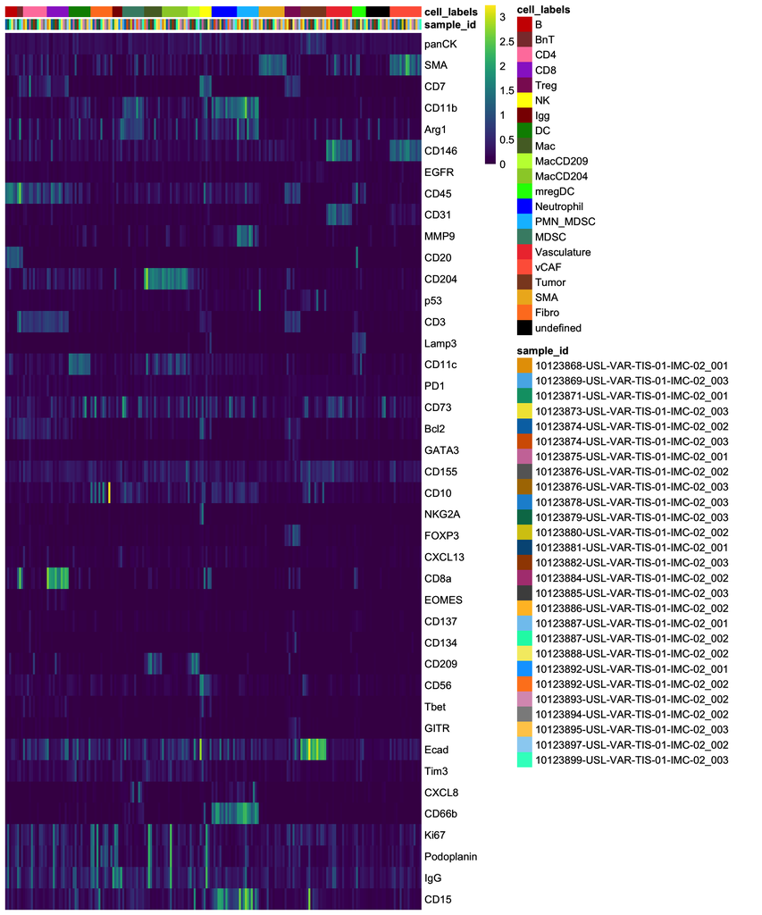

```r
# NOTE: теплова карта середньої експресії маркерів, згрупована за типами клітин (перевірка,
# що мітки біологічно осмислені).
dittoHeatmap(
  agr_sce[cur_markers, ],
  assay = "exprs",
  annot.by = c("sample_id", "cell_labels"),
  cluster_rows = FALSE,
  scale = "none",
  heatmap.colors = viridis::viridis(100),
  order.by = "cell_labels",
  annotation_colors = list(
    cell_labels = cell_type_colors
  )
)
```

# train classifier

## classifier rules

```r
# NOTE: біологічні правила очистки перед навчанням: викидаємо Igg з IgG<1 та NK з CD7<0.5,
# а mregDC з високим епітеліальним сигналом (panCK>0.5 або Ecad>0.8) перемічаємо на Tumor.
lab_sce <- spe_27[, !is.na(spe_27$cell_labels) & spe_27$cell_labels != "unlabelled"]
unlab_sce <- spe_27[, is.na(spe_27$cell_labels) | spe_27$cell_labels == "unlabelled"]

# - Igg < 1
exprs_mat <- assay(lab_sce, "exprs")
low_igg <- lab_sce$cell_labels == "Igg" & exprs_mat["IgG", ] < 1
lab_sce <- lab_sce[, !low_igg]

# - NKs withCD7 expression < 0.5
exprs_mat <- assay(lab_sce, "exprs")
low_cd7_nk <- lab_sce$cell_labels == "NK" & exprs_mat["CD7", ] < 0.5
lab_sce <- lab_sce[, !low_cd7_nk]

# Relabel mregDC cells with high epithelial/tumor marker expression to Tumor
exprs_mat <- assay(lab_sce, "exprs")
mregdc_to_tumor <- lab_sce$cell_labels == "mregDC" &
  (
    exprs_mat["panCK", ] > 0.5 |
      exprs_mat["Ecad", ] > 0.8
  )

lab_sce$cell_labels[mregdc_to_tumor] <- "Tumor"

table(lab_sce$cell_labels)
```

```
##
##           B         BnT         CD4         CD8          DC       Fibro
##          53          35         612         509         126         293
##         Igg        MDSC         Mac    MacCD204    MacCD209          NK
##          13          34         100        1078         123          12
##  Neutrophil    PMN_MDSC         SMA        Treg       Tumor Vasculature
##          50         200         217          87       22655         236
##      mregDC   undefined        vCAF
##          18         450         135
```

## save lab_sce

```r
# NOTE: таблиця кількості клітин кожного типу по кожному знімку (вхід для оптимізатора train/test поділу).
dat <- as.data.frame(unclass(table(lab_sce$sample_id,lab_sce$cell_labels)))
dat
```

```
##                                     B BnT CD4 CD8 DC Fibro Igg MDSC Mac
## 10123868-USL-VAR-TIS-01-IMC-02_001  0   0   5   4  0     0   0    0   8
## 10123869-USL-VAR-TIS-01-IMC-02_003  0   0   0   0  0     0   0    2   0
## 10123871-USL-VAR-TIS-01-IMC-02_001  0   0   0   0  0     0   1    0   0
## 10123873-USL-VAR-TIS-01-IMC-02_003  0   0  24   5  3    13   1    0   0
## 10123874-USL-VAR-TIS-01-IMC-02_002  1   0   4   1  2     4   0    2   0
## 10123874-USL-VAR-TIS-01-IMC-02_003  0   0   0   0  0     0   0    7   0
## 10123875-USL-VAR-TIS-01-IMC-02_001  0   0   3   0  3     4   0    0   4
## 10123876-USL-VAR-TIS-01-IMC-02_002  0   0   0   0  0     0   0    1   0
## 10123876-USL-VAR-TIS-01-IMC-02_003  0   0   0   0  0     0   0    0   0
## 10123878-USL-VAR-TIS-01-IMC-02_003  0   0   0   0  0     0   0    0   0
## 10123879-USL-VAR-TIS-01-IMC-02_003 36  31 220 162 11   144   0    0   6
## 10123880-USL-VAR-TIS-01-IMC-02_002  0   0   0   0  0     0   0    1   0
## 10123881-USL-VAR-TIS-01-IMC-02_001  0   0   0   0  0     0   0    0   0
## 10123882-USL-VAR-TIS-01-IMC-02_003  0   0  10  36  2     0   0    0  28
## 10123884-USL-VAR-TIS-01-IMC-02_002  0   0   0   0  0     0   0    1   0
## 10123885-USL-VAR-TIS-01-IMC-02_003  0   0  14   1  0     9   0    0   3
## 10123886-USL-VAR-TIS-01-IMC-02_002  0   0   0   0  0     0   0    0   0
## 10123887-USL-VAR-TIS-01-IMC-02_001  0   0   0   0  0     0   0    2   0
## 10123887-USL-VAR-TIS-01-IMC-02_002  1   1 144  75 39     6   0    0  34
## 10123888-USL-VAR-TIS-01-IMC-02_002  3   0  38 103 50    22   3    0   4
## 10123892-USL-VAR-TIS-01-IMC-02_001  0   0   0   0  0     0   7    0   0
## 10123892-USL-VAR-TIS-01-IMC-02_002  0   0   0   0  0     0   0    1   0
## 10123893-USL-VAR-TIS-01-IMC-02_002  0   0  10   2 10    14   0    6   0
## 10123894-USL-VAR-TIS-01-IMC-02_002  5   0  20   8  1     3   0    7   0
## 10123895-USL-VAR-TIS-01-IMC-02_003  0   0   0   0  3     8   1    0   3
## 10123897-USL-VAR-TIS-01-IMC-02_002  7   3 120 112  2    66   0    0  10
## 10123899-USL-VAR-TIS-01-IMC-02_003  0   0   0   0  0     0   0    4   0
##                                    MacCD204 MacCD209 NK Neutrophil PMN_MDSC SMA
## 10123868-USL-VAR-TIS-01-IMC-02_001       42        0  0          0        4   2
## 10123869-USL-VAR-TIS-01-IMC-02_003        0        0  0          0        0   0
## 10123871-USL-VAR-TIS-01-IMC-02_001        0        0  3          0        0   0
## 10123873-USL-VAR-TIS-01-IMC-02_003      227        0  0          0       17   3
## 10123874-USL-VAR-TIS-01-IMC-02_002       16        0  0          2       15   9
## 10123874-USL-VAR-TIS-01-IMC-02_003        0        0  0          6        0   0
## 10123875-USL-VAR-TIS-01-IMC-02_001      222        3  1          5      123  16
## 10123876-USL-VAR-TIS-01-IMC-02_002        0        0  3          2        0   0
## 10123876-USL-VAR-TIS-01-IMC-02_003        0        0  0          0        0   0
## 10123878-USL-VAR-TIS-01-IMC-02_003        0        0  0          0        0   0
## 10123879-USL-VAR-TIS-01-IMC-02_003       94        3  2          0        4  12
```

[output cut: 29 more lines]

```
## 10123881-USL-VAR-TIS-01-IMC-02_001    0     0           0      0         0    0
## 10123882-USL-VAR-TIS-01-IMC-02_003    7  1432          10      0        21    0
## 10123884-USL-VAR-TIS-01-IMC-02_002    0     0           0      0         0    0
## 10123885-USL-VAR-TIS-01-IMC-02_003    2  2827          20      1        15   17
## 10123886-USL-VAR-TIS-01-IMC-02_002    0     0           0      0         0    7
## 10123887-USL-VAR-TIS-01-IMC-02_001    0     0           0      0         0    8
## 10123887-USL-VAR-TIS-01-IMC-02_002    0   565          11      0       158    0
## 10123888-USL-VAR-TIS-01-IMC-02_002   26  1652          26      2         6    5
## 10123892-USL-VAR-TIS-01-IMC-02_001    0     0           0      0         0    0
## 10123892-USL-VAR-TIS-01-IMC-02_002    0     0           0      0         0    0
## 10123893-USL-VAR-TIS-01-IMC-02_002    4  1894           7      0        90    2
## 10123894-USL-VAR-TIS-01-IMC-02_002    6  3152           5      5        62    2
## 10123895-USL-VAR-TIS-01-IMC-02_003    0  1614          10      0        38    2
## 10123897-USL-VAR-TIS-01-IMC-02_002   37  2183          16      0        22   72
## 10123899-USL-VAR-TIS-01-IMC-02_003    0     0           0      1         0    1
```

## gate quality / cleanliness QC

```r
# NOTE: QC ЯКОСТІ ГЕЙТІВ (не моделі) — оцінюємо, наскільки «чисті» ручні мітки ДО навчання.
# Якість гейтів задає стелю точності моделі, тож дивимось на: (a) покриття типів,
# (b) внутрішню узгодженість гейта в просторі маркерів, (c) явні зведення консолідації.
# Перевикористовує lab_sce (гейтовані + очищені клітини) та assay "exprs".

# (a) Coverage: скільки клітин і знімків дає кожен тип (видно недопредставлені типи,
#     яким бракує прикладів для надійного навчання).
coverage <- as.data.frame(colData(lab_sce)) |>
  dplyr::group_by(cell_labels) |>
  dplyr::summarise(
    n_cells  = dplyr::n(),
    n_images = dplyr::n_distinct(sample_id),
    .groups  = "drop"
  ) |>
  dplyr::arrange(n_cells)
coverage
```

```
## # A tibble: 21 × 3
##    cell_labels n_cells n_images
##    <chr>         <int>    <int>
##  1 NK               12        6
##  2 Igg              13        5
##  3 mregDC           18        7
##  4 MDSC             34       11
##  5 BnT              35        3
##  6 Neutrophil       50       13
##  7 B                53        6
##  8 Treg             87        8
##  9 Mac             100        9
## 10 MacCD209        123        6
## # ℹ 11 more rows
```

```r
# (b) Nearest-centroid purity: для кожної клітини перевіряємо, чи її профіль маркерів
#     найближчий до центроїда ВЛАСНОГО типу. Низька purity => шумний/брудний гейт.
#     Data-driven, без ручних маркер-карт. Маркери без DNA/Histone, z-score по маркеру.
qc_markers <- rownames(lab_sce)[
  !grepl("DNA|Histone", rownames(lab_sce), ignore.case = TRUE)
]

z    <- scale(t(assay(lab_sce, "exprs")[qc_markers, ]))   # клітини x маркери (z-score)
labs <- factor(lab_sce$cell_labels)

# центроїд кожного типу в просторі маркерів (тип x маркер)
centroids <- rowsum(z, labs) / as.numeric(table(labs))

# відстань кожної клітини до кожного центроїда; найближчий = передбачений тип
D <- sapply(seq_len(nrow(centroids)), function(k) {
  sqrt(rowSums((z - matrix(centroids[k, ], nrow(z), ncol(z), byrow = TRUE))^2))
})
colnames(D) <- rownames(centroids)

nearest <- colnames(D)[max.col(-D)]                       # мінімальна відстань
purity  <- tapply(nearest == as.character(labs), labs, mean)

gate_purity <- data.frame(
  cell_label = names(purity),
  purity     = round(as.numeric(purity), 3),
  row.names  = NULL
) |>
  dplyr::left_join(coverage, by = c("cell_label" = "cell_labels")) |>
  dplyr::arrange(purity)
gate_purity
```

```
##     cell_label purity n_cells n_images
## 1           NK  0.500      12        6
## 2          Mac  0.570     100        9
## 3         MDSC  0.618      34       11
## 4        Fibro  0.747     293       11
## 5          CD4  0.761     612       12
## 6     MacCD209  0.764     123        6
## 7          Igg  0.769      13        5
## 8     MacCD204  0.774    1078       13
## 9          CD8  0.784     509       11
## 10        Treg  0.839      87        8
## 11    PMN_MDSC  0.850     200       11
## 12  Neutrophil  0.880      50       13
## 13         BnT  0.886      35        3
## 14           B  0.887      53        6
## 15 Vasculature  0.903     236       13
## 16        vCAF  0.933     135       16
## 17      mregDC  0.944      18        7
## 18          DC  0.952     126       11
## 19       Tumor  0.967   22655       13
## 20         SMA  0.968     217       13
## 21   undefined  0.980     450       12
```

```r
# (c) Явний друк зведень консолідації, щоб числа були видимі поруч із QC.
#     consolidation_stats і cur_labels обчислені вище у чанках консолідації.
#     Розподіл між train/test додатково показують split_stats та rare_balance нижче.
consolidation_stats
```

```
##                            category     n
## 1       total_unique_gated_cell_ids 80687
## 2   same_label_duplicates_collapsed    49
## 3                 single_label_kept 80564
## 4 tumor_plus_other_renamed_to_other    68
## 5        non_tumor_doublets_removed    55
```

```r
table(cur_labels)
```

```
## cur_labels
##           B         BnT         CD4         CD8          DC       Fibro
##         975         362        2557        3113         458        1046
##         Igg        MDSC         Mac    MacCD204    MacCD209          NK
##         213          48         858        3580         460         199
##  Neutrophil    PMN_MDSC         SMA        Treg       Tumor Vasculature
##         622         632        1049         634       59152        1289
##      mregDC   undefined        vCAF
##         120        3000         265
```

```r
# NOTE: скільки клітин загалом labelled vs unlabelled.
table(
  label_status = ifelse(
    spe_27$cell_labels == "unlabelled",
    "unlabelled",
    "labelled"
  )
)
```

```
## label_status
##   labelled unlabelled
##      27036      51168
```

## find a good test/train split

## split data into test & train sets

```r
# NOTE: визначаємо функцію split_test_rows() — оптимізатор train/test поділу НА РІВНІ ЗНІМКІВ,
# який цілиться у задані частки тест-набору окремо для частих і рідкісних типів клітин.
# Stratified train/test row split for multi-label count data.
#
# Each row is a sample with non-negative counts of each cell type in the
# columns. The split is at the row level, but it targets *cell-level* totals:
# achieved_test_frac[l] := test_count[l] / total[l] should be close to
# `default_test_frac` for common labels and `rare_test_frac` for the labels
# in `rare_labels` (default: "MDSC"). Additional labels whose total count is
# below `rare_threshold` are treated as rare too, if that argument is given.
#
# Objective (minimized):
#   sum_l  w_l * (test_count_l / total_l - target_frac_l)^2
# with w_l = `rare_weight` for rare labels, 1 otherwise.
#
# Algorithm: random init (biased toward test for rows containing rare labels),
# then steepest-descent single-row flips evaluated for all rows in one
# vectorized matrix multiply per step. Repeated from `n_restarts` initial
# seeds; the best basin wins. Converges in milliseconds for a few hundred
# rows; scales as O(restarts * flips * n * L).

split_test_rows <- function(counts,
                            default_test_frac = 0.20,
                            rare_test_frac    = 0.40,
                            rare_labels       = c("MDSC"),
                            rare_threshold    = NULL,
                            rare_weight       = 1,
                            n_restarts        = 100,
                            seed              = 42) {
  set.seed(seed)

  if (is.data.frame(counts)) {
    if (!is.numeric(counts[[1]])) {
      rn     <- as.character(counts[[1]])
      counts <- as.matrix(counts[, -1, drop = FALSE])
      rownames(counts) <- rn
    } else {
      counts <- as.matrix(counts)
    }
  }
  storage.mode(counts) <- "double"

  labels <- colnames(counts)
  totals <- colSums(counts)
  n      <- nrow(counts)

  if (!is.null(rare_threshold))
    rare_labels <- union(rare_labels, labels[totals < rare_threshold])
  rare_labels <- intersect(rare_labels, labels)
  is_rare     <- labels %in% rare_labels

  target_frac        <- ifelse(is_rare, rare_test_frac, default_test_frac)
  names(target_frac) <- labels

  # Zero out empty columns so they don't contribute a constant target_frac^2
  # penalty that no flip can fix.
  active     <- totals > 0
  w          <- ifelse(is_rare, rare_weight, 1) * active
  inv_totals <- ifelse(active, 1 / pmax(totals, 1), 0)

  # rate[i,l] = counts[i,l] / total[l]; precomputed once.
  rate      <- counts * rep(inv_totals, each = n)
  rate_sq_w <- as.numeric(rate^2 %*% w)   # length n, constant across iterations

  # Bias rows containing rare-label cells toward starting in test.
  has_rare  <- if (any(is_rare)) rowSums(counts[, is_rare, drop = FALSE]) > 0
               else rep(FALSE, n)
  init_prob <- ifelse(has_rare, rare_test_frac, default_test_frac)

  best_score   <- Inf
  best_in_test <- logical(n)

  for (restart in seq_len(n_restarts)) {
    in_test  <- runif(n) < init_prob
    test_sum <- colSums(counts[in_test, , drop = FALSE])

    repeat {
      cur_err   <- test_sum * inv_totals - target_frac
      cur_score <- sum(w * cur_err * cur_err)

      sgn        <- 1 - 2 * in_test                            # +1 = will add to test, -1 = will leave test
      linear     <- as.numeric(rate %*% (w * cur_err))
      flip_delta <- 2 * sgn * linear + rate_sq_w               # change in objective for each candidate flip

      best_i <- which.min(flip_delta)
      if (flip_delta[best_i] >= -1e-12) break                  # local minimum reached

      test_sum        <- test_sum + sgn[best_i] * counts[best_i, ]
      in_test[best_i] <- !in_test[best_i]
    }

    if (cur_score < best_score) {
      best_score   <- cur_score
      best_in_test <- in_test
    }
  }

  test_sum <- colSums(counts[best_in_test, , drop = FALSE])
  achieved <- ifelse(active, test_sum * inv_totals, NA_real_)

  summary_df <- data.frame(
    label              = labels,
    total              = totals,
    test_count         = test_sum,
    train_count        = totals - test_sum,
    target_test_frac   = target_frac,
    achieved_test_frac = round(achieved, 3),
    is_rare            = is_rare,
    row.names          = NULL
  )

  list(
    test_idx       = which(best_in_test),
    train_idx      = which(!best_in_test),
    test_rownames  = rownames(counts)[best_in_test],
    train_rownames = rownames(counts)[!best_in_test],
    summary        = summary_df,
    score          = best_score
  )
}
```

## looking for a seed with the best distribution between train/test

```r
# NOTE: параметри поділу винесені в split_params (єдине джерело — їх же показуємо в підсумку).
# Підвищена вага (rare_weight=20) для рідкісних типів (B, BnT, MDSC, Igg, mregDC, NK), 1000 рестартів.
split_params <- list(
  default_test_frac = 0.20,
  rare_test_frac    = 0.20,
  rare_labels       = c("B", "BnT", "MDSC", "Igg", "mregDC", "NK"),
  rare_weight       = 20,
  n_restarts        = 1000,
  seed              = 42
)

res <- do.call(split_test_rows, c(list(counts = dat), split_params))

res$summary
```

```
##          label total test_count train_count target_test_frac achieved_test_frac
## 1            B    53          8          45              0.2              0.151
## 2          BnT    35          3          32              0.2              0.086
## 3          CD4   612        124         488              0.2              0.203
## 4          CD8   509        113         396              0.2              0.222
## 5           DC   126          7         119              0.2              0.056
## 6        Fibro   293         78         215              0.2              0.266
## 7          Igg    13          2          11              0.2              0.154
## 8         MDSC    34          7          27              0.2              0.206
## 9          Mac   100         13          87              0.2              0.130
## 10    MacCD204  1078        159         919              0.2              0.147
## 11    MacCD209   123         21         102              0.2              0.171
## 12          NK    12          3           9              0.2              0.250
## 13  Neutrophil    50         11          39              0.2              0.220
## 14    PMN_MDSC   200         17         183              0.2              0.085
```

[output cut: 29 more lines]

```r
# NOTE: друкуємо підсумок поділу (скільки знімків у тесті, значення цільової функції).
cat(sprintf("Test rows: %d / %d (%.1f%%) | objective = %.5f\n",
            length(res$test_idx), nrow(dat),
            100 * length(res$test_idx) / nrow(dat),
            res$score))
```

```
## Test rows: 7 / 27 (25.9%) | objective = 0.66731
```

```r
print(res$summary)
```

```
##          label total test_count train_count target_test_frac achieved_test_frac
## 1            B    53          8          45              0.2              0.151
## 2          BnT    35          3          32              0.2              0.086
## 3          CD4   612        124         488              0.2              0.203
## 4          CD8   509        113         396              0.2              0.222
## 5           DC   126          7         119              0.2              0.056
## 6        Fibro   293         78         215              0.2              0.266
## 7          Igg    13          2          11              0.2              0.154
## 8         MDSC    34          7          27              0.2              0.206
## 9          Mac   100         13          87              0.2              0.130
## 10    MacCD204  1078        159         919              0.2              0.147
## 11    MacCD209   123         21         102              0.2              0.171
## 12          NK    12          3           9              0.2              0.250
## 13  Neutrophil    50         11          39              0.2              0.220
## 14    PMN_MDSC   200         17         183              0.2              0.085
```

[output cut: 29 more lines]

```r
# NOTE: фактично ділимо клітини на train_sce/test_sce за списком знімків з оптимізатора.
test_sce <- lab_sce[, lab_sce$sample_id %in% res$test_rownames]
train_sce <- lab_sce[, lab_sce$sample_id %in% res$train_rownames]
```

```r
# NOTE: зводимо таблицю кількості клітин кожного типу окремо у train і test (перевірка балансу поділу).
all_labels <- sort(unique(c(
  as.character(train_sce$cell_labels),
  as.character(test_sce$cell_labels)
)))

all_labels <- all_labels[
  !is.na(all_labels) &
    all_labels != "unlabelled"
]

train_tab <- table(
  factor(as.character(train_sce$cell_labels), levels = all_labels)
)

test_tab <- table(
  factor(as.character(test_sce$cell_labels), levels = all_labels)
)

split_stats <- data.frame(
  cell_label = all_labels,
  train_n = as.integer(train_tab),
  test_n = as.integer(test_tab),
  row.names = NULL
)

split_stats
```

```
##     cell_label train_n test_n
## 1            B      45      8
## 2          BnT      32      3
## 3          CD4     488    124
## 4          CD8     396    113
## 5           DC     119      7
## 6        Fibro     215     78
## 7          Igg      11      2
## 8         MDSC      27      7
## 9          Mac      87     13
## 10    MacCD204     919    159
## 11    MacCD209     102     21
## 12          NK       9      3
## 13  Neutrophil      39     11
## 14    PMN_MDSC     183     17
## 15         SMA     172     45
## 16        Treg      50     37
## 17       Tumor   17130   5525
## 18 Vasculature     201     35
## 19      mregDC      15      3
## 20   undefined     380     70
## 21        vCAF      58     77
```

## rare cell types distribition between samples

```r
# NOTE: окремо перевіряємо баланс рідкісних типів між train/test — і кількість клітин, і кількість знімків.
rare_celltypes <- c("BnT", "Igg", "MDSC", "mregDC", "vCAF")

rare_balance <- bind_rows(
  as.data.frame(colData(train_sce)) |>
    mutate(split = "train"),
  as.data.frame(colData(test_sce)) |>
    mutate(split = "test")
) |>
  dplyr::filter(cell_labels %in% rare_celltypes) |>
  group_by(split, cell_labels) |>
  summarise(
    total_cells = n(),
    n_samples = n_distinct(sample_id),
    .groups = "drop"
  ) |>
  arrange(split, cell_labels)

rare_balance
```

```
## # A tibble: 10 × 4
##    split cell_labels total_cells n_samples
##    <chr> <chr>             <int>     <int>
##  1 test  BnT                   3         1
##  2 test  Igg                   2         2
##  3 test  MDSC                  7         3
##  4 test  mregDC                3         2
##  5 test  vCAF                 77         5
##  6 train BnT                  32         2
##  7 train Igg                  11         3
##  8 train MDSC                 27         8
##  9 train mregDC               15         5
## 10 train vCAF                 58        11
```

## prepare data for classifier

1. split the labelled data into training + test data at the image level by `sample_id`. All cells from the same image are assigned training or test set

Within the training set another 5-fold grouped cross-validation for XGBoost parameter tuning was applied

```r
# =====================================================================
# STEP 05 — Vectorize (cell × marker matrix)
# =====================================================================
# NOTE: готуємо дані для XGBoost — будуємо матриці ознак X (клітини в рядках, маркери в стовпцях,
# без DNA/Histone, тому транспонуємо), цілі y (0-based), label_mapping (число<->тип),
# інверсно-частотні ваги класів (з пониженням undefined та Igg) і об'єкти xgb.DMatrix.

# Create unique cell identifiers so each cell can be traced back to its image
# and object number after training, prediction, or error analysis.
train_sce$cell_id <- paste0(train_sce$sample_id, "_", train_sce$ObjectNumber)
test_sce$cell_id <- paste0(test_sce$sample_id, "_", test_sce$ObjectNumber)

colnames(train_sce) <- train_sce$cell_id
colnames(test_sce) <- test_sce$cell_id

marker_keep <- !grepl("DNA|Histone", rownames(train_sce))

# XGBoost expects cells as rows and features as columns.
# The assay matrix has markers as rows and cells as columns, so we transpose it.
X <- t(assay(train_sce, "exprs")[marker_keep, ])
X_test_all <- t(assay(test_sce, "exprs")[marker_keep, ])

stopifnot(identical(colnames(X), colnames(X_test_all)))
stopifnot(!anyDuplicated(colnames(X)))

# XGBoost requires numeric class labels starting at 0.
# The factor levels from the training set define the fixed mapping between
# numeric class IDs and biological cell labels.
y_true <- factor(train_sce$cell_labels)
label_mapping <- levels(y_true)

# Convert training labels from factors to 0-based numeric labels.
y <- as.integer(y_true) - 1

# Number of classes required by the multiclass XGBoost objective.
num_classes <- length(label_mapping)

stopifnot(!anyNA(y))
stopifnot(min(y) == 0)
stopifnot(max(y) == num_classes - 1)

# Keep only labelled test cells for evaluation.
# Unlabelled cells are excluded from Xy_test because XGBoost cannot accept NA labels.
test_eval_keep <- !is.na(test_sce$cell_labels) &
  test_sce$cell_labels != "unlabelled" &
  test_sce$cell_labels %in% label_mapping

X_test_eval <- t(assay(test_sce, "exprs")[marker_keep, test_eval_keep])

y_test_true <- factor(
  test_sce$cell_labels[test_eval_keep],
  levels = label_mapping
)

y_test <- as.integer(y_test_true) - 1

stopifnot(!anyNA(y_test))
stopifnot(min(y_test) >= 0)
stopifnot(max(y_test) <= num_classes - 1)

# Inverse-frequency class weights so rare cell types contribute more
# to the loss function during training.
w_class <- 1 / (table(y_true) / length(y_true))

# Down-weight undefined and IgG classes so they do not dominate the classifier
# despite being noisy or less biologically informative labels.
if ("undefined" %in% names(w_class)) {
  w_class["undefined"] <- w_class["undefined"] / 10
}

if ("Igg" %in% names(w_class)) {
  w_class["Igg"] <- w_class["Igg"] / 30
}

# Convert class-level weights into one weight per training cell.
# Rescale weights to mean 1 for numerical stability.
w <- as.numeric(w_class[y_true])
w <- w / mean(w)

# Training data: features, labels, and cell weights.
Xy <- xgboost::xgb.DMatrix(
  data = X,
  label = y,
  weight = w
)

# Labelled held-out test data, for evaluation only.
Xy_test <- xgboost::xgb.DMatrix(
  data = X_test_eval,
  label = y_test
)

# All held-out/test cells, including unlabelled cells, for prediction/classification.
Xy_test_all <- xgboost::xgb.DMatrix(
  data = X_test_all
)

test_eval_cell_ids <- colnames(test_sce)[test_eval_keep]
test_all_cell_ids <- colnames(test_sce)

table(y_test_true)
```

```
## y_test_true
##           B         BnT         CD4         CD8          DC       Fibro
##           8           3         124         113           7          78
##         Igg        MDSC         Mac    MacCD204    MacCD209          NK
##           2           7          13         159          21           3
##  Neutrophil    PMN_MDSC         SMA        Treg       Tumor Vasculature
##          11          17          45          37        5525          35
##      mregDC   undefined        vCAF
##           3          70          77
```

## check the rules

Here it is clearly seen the upward rules for the specific markers work

# TEMP / QC plots

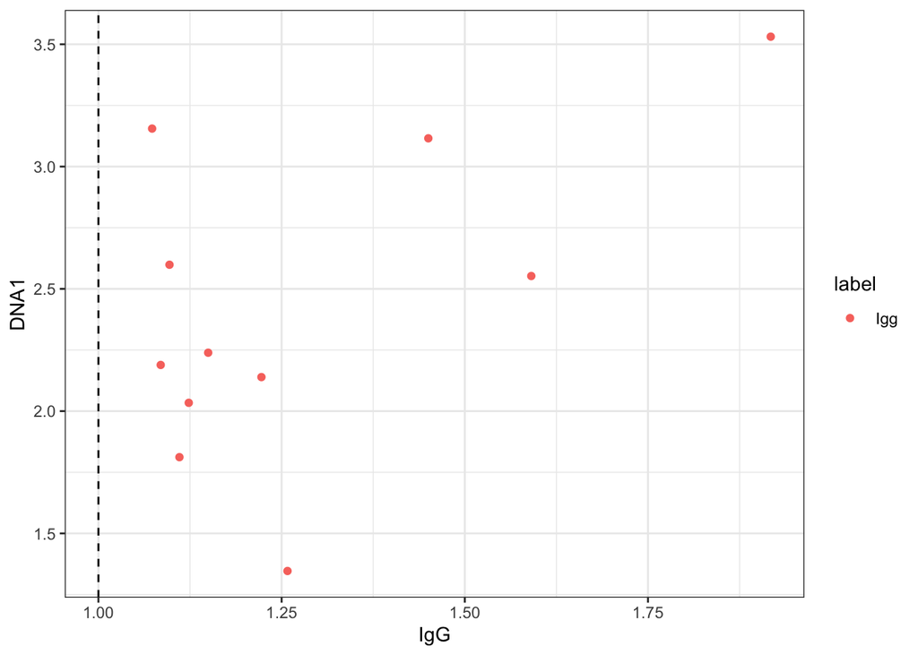

```r
# NOTE: QC-графіки, що правила очистки спрацювали — точкові діаграми для Igg (IgG vs DNA1)
# та mregDC (Ecad vs panCK) з пороговими лініями.
coldat <- as.data.frame(t(assay(train_sce, "exprs")))
coldat$label <- train_sce$cell_labels

ggplot(coldat |> dplyr::filter(label == "Igg"),
       aes(x = IgG, y = DNA1, col = label)) +
  geom_point() +
  geom_vline(xintercept = 1, linetype = "dashed") +
  theme_bw()
```

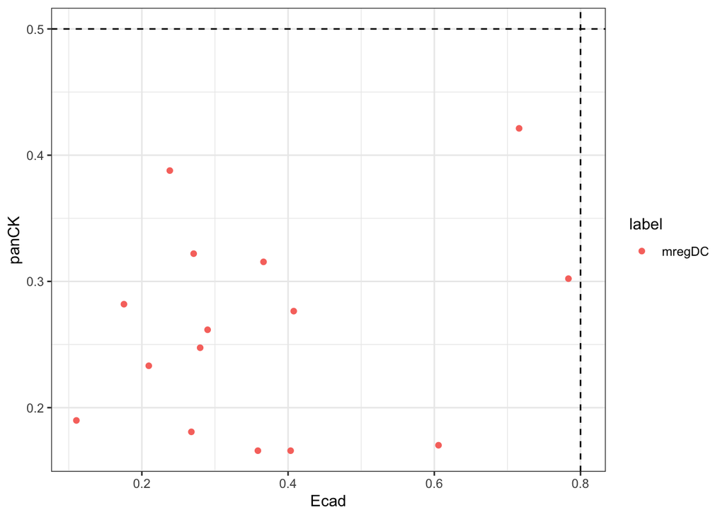

```r
ggplot(coldat |> dplyr::filter(label == "mregDC"),
       aes(x = Ecad, y = panCK, col = label)) +
  geom_point() +
  geom_hline(yintercept = 0.5, linetype = "dashed") +
  geom_vline(xintercept = 0.8, linetype = "dashed") +
  theme_bw()
```

## params for classofier, cross validation

All heavy calculations are here

```r
# =====================================================================
# STEP 06 — Train (grouped XGBoost)
# =====================================================================
# NOTE: НАЙВАЖЧІ обчислення — grid-search крос-валідація XGBoost. Створюємо згруповані за
# знімками фолди (groupKFold, щоб клітини одного знімка не текли між train/valid), перебираємо
# сітку гіперпараметрів (12 комбінацій) через xgb.cv з early stopping і зберігаємо найкращий
# nrounds та mlogloss кожної моделі.

# Make sure cells from the same image are not split across CV train/test folds.
# groupKFold returns training indices, while xgb.cv expects validation indices,
# so we convert each fold to the held-out indices.
cv_train_index <- caret::groupKFold(
  group = factor(train_sce$sample_id),
  k = 5
)

all_indices <- seq_len(ncol(train_sce))

fold_list <- lapply(
  cv_train_index,
  function(train_idx) setdiff(all_indices, train_idx)
)

# XGBoost builds an ensemble of decision trees sequentially
# Each new tree tries to correct the errors made by the previous trees

param_grid <- expand.grid( #creates all combinations of the parameter values 3 * 2 * 1 * 1 * 2 = 12 models

  # Maximum depth of each tree.
  # Smaller values make simpler trees and reduce overfitting
  # Larger values allow more complex interactions between markers
  max_depth = c(3, 4, 5),

  # Learning rate controls how much each new tree contributes to the final model
  # < eta usually needs more trees but can generalize better
  eta = c(0.05, 0.1),

  # Fraction of cells sampled for each tree
  # Subsampling reduces overfitting by making trees less correlated
  subsample = c(0.8), #for each tree, XGBoost randomly uses 80% of the training cells and leaves out the other 20%

  # fraction of markers/features sampled for each tree, reduces overfitting and makes the model more robust.
  colsample_bytree = c(0.8), #40 * 0.8 = 32 markers

  # Minimum amount of weighted data required in a child node.
  # Higher values make the model more conservative, especially for rare classes
  min_child_weight = c(1, 5)
)

# Max N of boosting rounds, 1 round adds one tree per class for multiclass classification
# Early stopping below can stop before this limit if validation loss stops improving
nround <- 300

# Store the full CV models and a compact summary of their performance.
models <- list()
cv_summary <- list()

# Loop over all parameter combinations
for (i in seq_len(nrow(param_grid))) {

  # Parameters for the current XGBoost model
  params <- list(
    booster = "gbtree",

    # Multiclass classification with predicted probabilities for each cell type
    objective = "multi:softprob",

    # Optimize and monitor multiclass log-loss.
    #  <  mlogloss means predicted probabilities are closer to true labels.
    eval_metric = "mlogloss", #CD8 probability = 0.95 - low loss, good

    # Number of cell-type classes.
    num_class = num_classes,

    max_depth = param_grid$max_depth[i],
    eta = param_grid$eta[i],
    subsample = param_grid$subsample[i],
    colsample_bytree = param_grid$colsample_bytree[i],
    min_child_weight = param_grid$min_child_weight[i],

    # Histogram-based tree construction, faster for larger datasets.
    tree_method = "hist",
    nthread = max(1, parallel::detectCores() - 1)
  )

  message(
    "Running: max_depth=", params$max_depth,
    "; eta=", params$eta,
    "; subsample=", params$subsample,
    "; colsample_bytree=", params$colsample_bytree,
    "; min_child_weight=", params$min_child_weight
  )

  # Cross-validation on image-level folds.
  # Each fold holds out complete images, so cells from the same image are not
  # split between training and validation.
  cv_results <- xgboost::xgb.cv(
    params = params,
    data = Xy,
    folds = fold_list, #@Round 1: train Fold2 + Fold3 + Fold4 + Fold5, test Fold1, etc.
    nrounds = nround, #300 ceiling, 107 - best

    # Stop if validation log-loss does not improve for 20 rounds.
    # This helps prevent overfitting and saves computation time.
    early_stopping_rounds = 20, #can go more after the best (108), if not will keep 108

    verbose = F, #if T - there is a message about the ML process

    # During grid search we only need test loss, not cell-level predictions
    prediction = F
  )

  models[[i]] <- cv_results

  # Select the boosting round with the lowest validation log-loss.
  best_iteration <- which.min(cv_results$evaluation_log$test_mlogloss_mean)
  best_mlogloss <- cv_results$evaluation_log$test_mlogloss_mean[best_iteration]

  # Store parameter values and their best CV score.
  cv_summary[[i]] <- data.frame(
    param_grid[i, ],
    best_iteration = best_iteration,
    best_mlogloss = best_mlogloss
  )
}

# Combine all model summaries into one table for selecting the best parameters.
cv_summary <- bind_rows(cv_summary)
```

```r
# NOTE: таблиця всіх комбінацій гіперпараметрів, відсортована за найкращим mlogloss (кращі зверху).
cv_summary |>
  dplyr::arrange(best_mlogloss)
```

```
##    max_depth  eta subsample colsample_bytree min_child_weight best_iteration
## 1          3 0.05       0.8              0.8                5            181
## 2          3 0.10       0.8              0.8                5             81
## 3          5 0.05       0.8              0.8                5            203
## 4          4 0.05       0.8              0.8                5            204
## 5          4 0.10       0.8              0.8                5            100
## 6          5 0.10       0.8              0.8                5            103
## 7          5 0.05       0.8              0.8                1            193
## 8          3 0.05       0.8              0.8                1            193
## 9          4 0.05       0.8              0.8                1            193
## 10         4 0.10       0.8              0.8                1            100
## 11         5 0.10       0.8              0.8                1            100
## 12         3 0.10       0.8              0.8                1             74
##    best_mlogloss
## 1      0.6345802
## 2      0.6390729
## 3      0.6495435
## 4      0.6534771
## 5      0.6633520
## 6      0.6728553
## 7      0.7152687
## 8      0.7227307
## 9      0.7233109
## 10     0.7512769
## 11     0.7548364
## 12     0.7561999
```

## cross-validation on the best param

```r
# NOTE: обираємо комбінацію гіперпараметрів з найменшим CV-mlogloss і перезапускаємо CV лише для неї
# з prediction=TRUE, щоб отримати out-of-fold прогнози для оцінки точності по типах клітин.
# parameter combination with the lowest cross-validation log-loss
best_params <- cv_summary |>
  arrange(best_mlogloss) |>
  dplyr::slice(1)

best_params
```

```
##   max_depth  eta subsample colsample_bytree min_child_weight best_iteration
## 1         3 0.05       0.8              0.8                5            181
##   best_mlogloss
## 1     0.6345802
```

```r
# > best_params
#   max_depth eta subsample colsample_bytree
# 1         4 0.1       0.8              0.8
#   min_child_weight best_iteration best_mlogloss
# 1                5            108      0.292158

# Use the best number of boosting rounds found during CV.
# This is the round with the lowest validation log-loss before early stopping.
best_nrounds <- as.integer(best_params$best_iteration)

# Define the final set of XGBoost parameters selected by grid search.
params_best <- list(
  booster = "gbtree",

  # Multiclass classification with class probabilities as output.
  objective = "multi:softprob",

  # Evaluation metric used during tuning.
  eval_metric = "mlogloss",

  # Number of cell-label classes.
  num_class = num_classes,

  # Best tree and regularization parameters from CV.
  max_depth = as.integer(best_params$max_depth),
  eta = best_params$eta,
  subsample = best_params$subsample,
  colsample_bytree = best_params$colsample_bytree,
  min_child_weight = best_params$min_child_weight,

  # Faster tree construction for larger datasets.
  tree_method = "hist",
  nthread = max(1, parallel::detectCores() - 1)
)

# Rerun cross-validation only for the selected best model.
# Here prediction = TRUE stores out-of-fold predictions for each training cell.
# These predictions are used to estimate per-cell-type performance.
best_cv <- xgboost::xgb.cv(
  params = params_best,
  data = Xy,
  folds = fold_list,
  nrounds = best_nrounds,
  verbose = FALSE,
  prediction = TRUE
)
```

## Check CV accuracy per cell type for the best model

```r
# NOTE: з out-of-fold ймовірностей беремо передбачений клас для кожної клітини (max.col),
# повертаємо назви типів через label_mapping і будуємо confusion matrix проти істинних міток.
# Extract out-of-fold predicted class probabilities from the best CV model.
# Rows are cells, columns are cell-label classes.
cv_prob <- best_cv$cv_predict

if (is.list(cv_prob)) {
  cv_prob <- do.call(rbind, cv_prob)
}

if (is.null(dim(cv_prob))) {
  cv_prob <- matrix(
    cv_prob,
    ncol = num_classes,
    byrow = TRUE
  )
}

cv_prob <- as.matrix(cv_prob)
storage.mode(cv_prob) <- "double"

# Check that the prediction matrix has one row per training cell
# and one column per cell-label class.
stopifnot(nrow(cv_prob) == length(y))
stopifnot(ncol(cv_prob) == num_classes)

# Convert predicted probabilities to predicted cell labels.
# max.col() finds the class with the highest probability for each cell.
# label_mapping converts numeric class positions back to cell-type names.
cv_pred <- factor(
  label_mapping[max.col(cv_prob)],
  levels = label_mapping
)

# Compare predicted labels against the true training labels.
# Because predictions are out-of-fold, each cell was predicted by a model
# that was not trained on that cell/image.
cm_cv <- caret::confusionMatrix(
  data = cv_pred,
  reference = y_true
)

# cm_cv$table
#              Reference
# Prediction        B   BnT   CD4   CD8    DC Fibro   Igg   Mac MacCD204 MacCD209
#   B             587     2     0     0     2     0     1     0        0        0
#   BnT             0   230     1     0     0     0     0     0        0        0
#   CD4             5    12  1796    21     2     0     3     0        0        2
#   CD8             0     1     9  2464     3     0     0     0        2        1
#   DC              1     0     0     0   346     0     0     0       11        2
#   Fibro           0     0     1     1     3   738    55     0        0        2
#   Igg             0     0     0     0     0    21    66     0        0        0
#   Mac             0     0     0     0     0     0     0   509       66       27
#   MacCD204        0     0     1     0    11     3     1    36     2711        1
#   MacCD209        0     1     2     0     1     1    13    50        1      328
#   MDSC            0     0     0     0     0     0     0     0        0        0
#   mregDC          0     0     1     0     0     1     0     1        2        2
#   Neutrophil      0     0     0     0     0     0     0     0        0        0
#   NK              0     0     1     0     1     4     0     0        0        0
#   PMN_MDSC        0     0     1     0     0     0     0     0        0        0
#   SMA             0     0     0     0     0    12     0     0        0        0
#   Treg            0     1     9     1     0     0     1     0        1        1
#   Tumor           0     0     1     0     0    80     0     0        0        0
#   undefined       0     0    20     1     0     2     1     0        0        0
#   Vasculature     0     0     0     1     0     0     0     0        0        0
#   vCAF            0     0     0     0     0     0     0     0        0        0
```

check where fibroblasts come from

```r
# NOTE: діагностика — звідки беруться помилки (напр. Tumor, передбачені як Fibro): дивимось,
# з яких знімків походять такі клітини.
train_sce$predicted <- cv_pred
table(train_sce$predicted,train_sce$cell_labels)
```

```
##
##                   B   BnT   CD4   CD8    DC Fibro   Igg  MDSC   Mac MacCD204
##   B              35     2     0     0     0     0     1     0     0        0
##   BnT             0     0     0     0     0     0     0     0     0        0
##   CD4             0     9   467    15     0     0     0     0     0        1
##   CD8             0    21     9   373     0     0     0     0     0        2
##   DC              0     0     0     0   117     0     0     0     0        0
##   Fibro           5     0     0     1     0   202     5     1     2        2
##   Igg             0     0     0     0     0     3     0     0     0        0
##   MDSC            0     0     0     2     1     0     0    25     0        0
##   Mac             0     0     0     0     0     0     0     0    81       11
##   MacCD204        1     0     1     1     0     1     0     0     3      899
##   MacCD209        2     0     0     0     0     0     0     0     0        0
##   NK              0     0     0     0     0     0     0     0     0        0
##   Neutrophil      0     0     0     0     0     0     0     0     0        0
##   PMN_MDSC        0     0     2     2     0     0     0     0     0        0
##   SMA             0     0     1     0     0     8     0     1     1        2
##   Treg            0     0     6     0     0     0     0     0     0        0
##   Tumor           0     0     0     1     1     0     0     0     0        2
##   Vasculature     0     0     1     0     0     0     0     0     0        0
##   mregDC          0     0     0     0     0     0     0     0     0        0
##   undefined       0     0     1     1     0     1     5     0     0        0
##   vCAF            2     0     0     0     0     0     0     0     0        0
##
##               MacCD209    NK Neutrophil PMN_MDSC   SMA  Treg Tumor Vasculature
##   B                  0     0          0        0     0     0     0           0
##   BnT                0     0          0        0     0     0     0           0
##   CD4                1     1          0        0     0     6     0           0
##   CD8                0     1          0        0     0     2     0           0
##   DC                 5     0          0        0     1     0     0           0
##   Fibro              0     0          0        0     1     0    20           0
##   Igg                1     0          0        0     0     0     0           0
##   MDSC               1     1          0        0     0     0     0           0
##   Mac                0     0          0        0     0     0     0           0
##   MacCD204           0     0          0        0     0     0     0           0
##   MacCD209          92     0          0        0     0     0     2           0
##   NK                 0     2          0        0     0     0    48           0
##   Neutrophil         0     1         33       10     0     0     3           0
##   PMN_MDSC           0     0          5      173     0     0     0           0
##   SMA                0     0          0        0   168     0     1           0
```

[output cut: 14 more lines]

```
##   Igg              0         0     0
##   MDSC             0         2     0
##   Mac              0         0     0
##   MacCD204         0         0     0
##   MacCD209         0         0     0
##   NK               0         0     0
##   Neutrophil       0         0     0
##   PMN_MDSC         0         0     0
##   SMA              1         0     2
##   Treg             0         0     0
##   Tumor            0         0     0
##   Vasculature      0         0     0
##   mregDC          11         0     0
##   undefined        0       378     0
##   vCAF             1         0    56
```

```r
table(train_sce$cell_labels)
```

```
##
##           B         BnT         CD4         CD8          DC       Fibro
##          45          32         488         396         119         215
##         Igg        MDSC         Mac    MacCD204    MacCD209          NK
##          11          27          87         919         102           9
##  Neutrophil    PMN_MDSC         SMA        Treg       Tumor Vasculature
##          39         183         172          50       17130         201
##      mregDC   undefined        vCAF
##          15         380          58
```